# CODE FOR PROJECT

## Loan Default Prediction

Importing all the necessary libraries

```python
import pandas as pd
import numpy as np
import matplotlib.pyplot as plt
import seaborn as sns
import re
import os
import datetime as dt
%matplotlib inline
from sklearn.model_selection import train_test_split
from sklearn.metrics import accuracy_score
from sklearn.linear_model import LogisticRegression
import sklearn.metrics as metrics
from sklearn.utils import resample
from datetime import date
from sklearn import preprocessing
from sklearn.feature_selection import SelectFromModel
from sklearn.ensemble import RandomForestClassifier
import statsmodels.api as sm
from sklearn.ensemble import ExtraTreesClassifier
from sklearn.feature_selection import RFE
from sklearn.linear_model import RidgeCV, LassoCV, Ridge, Lasso
from sklearn.metrics import roc_auc_score
from sklearn import datasets
from sklearn.feature_selection import RFE
from sklearn.linear_model import LogisticRegression
from scipy import stats
from sklearn.tree import export_graphviz
from IPython import display
```

```python
# import warnings filter
from warnings import simplefilter
# ignore all future warnings
simplefilter(action='ignore', category=FutureWarning)
```

# Load Dataset

```python
os.getcwd()#getting the path
os.chdir(r'C:\Users\Wale\Desktop\DAV Project\Dataset')#setting the path of the data file
df_default = pd.read_csv("train.csv")#reading the file
```

```python
df_default.head()
```

|  | UniqueID | disbursed_amount | asset_cost | ltv | branch_id | supplier_id | manufacturer_id | Current_pincode_ID | Date.of.Birth | Employment.Type | ... | SEC.SANCTIONED.AMOUNT | SEC.DISBURSED.AMOUNT | PRIMARY.INSTAL.AMT | SEC.INSTAL.AMT | NEW.ACCTS.IN.LAST.SIX.MONTHS | DELINQUENT.ACCTS.IN.LAST.SIX.MONTHS | AVERAGE.ACCT.AGE | CREDIT.HISTORY.LENGTH | NO.OF_INQUIRIES | loan_default |
| --- | --- | --- | --- | --- | --- | --- | --- | --- | --- | --- | --- | --- | --- | --- | --- | --- | --- | --- | --- | --- | --- |
| 0 | 420825 | 50578 | 58400 | 89.55 | 67 | 22807 | 45 | 1441 | 01-01-84 | Salaried | ... | 0 | 0 | 0 | 0 | 0 | 0 | 0yrs 0mon | 0yrs 0mon | 0 | 0 |
| 1 | 537409 | 47145 | 65550 | 73.23 | 67 | 22807 | 45 | 1502 | 31-07-85 | Self employed | ... | 0 | 0 | 1991 | 0 | 0 | 1 | 1yrs 11mon | 1yrs 11mon | 0 | 1 |
| 2 | 417566 | 53278 | 61360 | 89.63 | 67 | 22807 | 45 | 1497 | 24-08-85 | Self employed | ... | 0 | 0 | 0 | 0 | 0 | 0 | 0yrs 0mon | 0yrs 0mon | 0 | 0 |
| 3 | 624493 | 57513 | 66113 | 88.48 | 67 | 22807 | 45 | 1501 | 30-12-93 | Self employed | ... | 0 | 0 | 31 | 0 | 0 | 0 | 0yrs 8mon | 1yrs 3mon | 1 | 1 |
| 4 | 539055 | 52378 | 60300 | 88.39 | 67 | 22807 | 45 | 1495 | 09-12-77 | Self employed | ... | 0 | 0 | 0 | 0 | 0 | 0 | 0yrs 0mon | 0yrs 0mon | 1 | 1 |

5 rows × 41 columns

# Data Cleaning and Transformation

```python
# change the column heads to lower case
df_default.columns = map(str.lower, df_default.columns)
```

```python
df_default.info()
```

```
<class 'pandas.core.frame.DataFrame'>
RangeIndex: 233154 entries, 0 to 233153
Data columns (total 41 columns):
uniqueid                               233154 non-null int64
disbursed_amount                       233154 non-null int64
asset_cost                             233154 non-null int64
ltv                                    233154 non-null float64
branch_id                              233154 non-null int64
supplier_id                            233154 non-null int64
manufacturer_id                        233154 non-null int64
current_pincode_id                     233154 non-null int64
date.of.birth                          233154 non-null object
employment.type                        225493 non-null object
disbursaldate                          233154 non-null object
state_id                               233154 non-null int64
employee_code_id                       233154 non-null int64
mobileno_avl_flag                      233154 non-null int64
aadhar_flag                            233154 non-null int64
pan_flag                               233154 non-null int64
voterid_flag                           233154 non-null int64
driving_flag                           233154 non-null int64
passport_flag                          233154 non-null int64
perform_cns.score                      233154 non-null int64
perform_cns.score.description          233154 non-null object
pri.no.of.accts                        233154 non-null int64
pri.active.accts                       233154 non-null int64
pri.overdue.accts                      233154 non-null int64
pri.current.balance                    233154 non-null int64
pri.sanctioned.amount                  233154 non-null int64
pri.disbursed.amount                   233154 non-null int64
sec.no.of.accts                        233154 non-null int64
sec.active.accts                       233154 non-null int64
sec.overdue.accts                      233154 non-null int64
sec.current.balance                    233154 non-null int64
sec.sanctioned.amount                  233154 non-null int64
sec.disbursed.amount                   233154 non-null int64
primary.instal.amt                     233154 non-null int64
sec.instal.amt                         233154 non-null int64
new.accts.in.last.six.months           233154 non-null int64
delinquent.accts.in.last.six.months    233154 non-null int64
average.acct.age                       233154 non-null object
credit.history.length                  233154 non-null object
no.of_inquiries                        233154 non-null int64
loan_default                           233154 non-null int64
dtypes: float64(1), int64(34), object(6)
memory usage: 72.9+ MB
```

### We can see that employment.type has null values in them

```python
df_default.isnull().sum()
```

```
uniqueid                                  0
disbursed_amount                          0
asset_cost                                0
ltv                                       0
branch_id                                 0
supplier_id                               0
manufacturer_id                           0
current_pincode_id                        0
date.of.birth                             0
employment.type                        7661
disbursaldate                             0
state_id                                  0
employee_code_id                          0
mobileno_avl_flag                         0
aadhar_flag                               0
pan_flag                                  0
voterid_flag                              0
driving_flag                              0
passport_flag                             0
perform_cns.score                         0
perform_cns.score.description             0
pri.no.of.accts                           0
pri.active.accts                          0
pri.overdue.accts                         0
pri.current.balance                       0
pri.sanctioned.amount                     0
pri.disbursed.amount                      0
sec.no.of.accts                           0
sec.active.accts                          0
sec.overdue.accts                         0
sec.current.balance                       0
sec.sanctioned.amount                     0
sec.disbursed.amount                      0
primary.instal.amt                        0
sec.instal.amt                            0
new.accts.in.last.six.months              0
delinquent.accts.in.last.six.months       0
average.acct.age                          0
credit.history.length                     0
no.of_inquiries                           0
loan_default                              0
dtype: int64
```

Since we have a great number of null values (7661) in the Employment Type column, we can assume that because there were just two option unemployed members had to put NA, so we can create another category with the null values.

```python
 df_default['employment.type'].value_counts()
```

```
Self employed    127635
Salaried          97858
Name: employment.type, dtype: int64
```

```python
# fill Na with unemployed
df_default['employment.type'].fillna('unemployed', inplace = True)
```

```python
#Check
df_default['employment.type'].value_counts()
```

```
Self employed    127635
Salaried          97858
unemployed         7661
Name: employment.type, dtype: int64
```

##### Dropping the columns that we are not using for analysis

```python
df_default= df_default.drop(columns = ['pan_flag',
 'voterid_flag',
 'driving_flag',
 'passport_flag', 'mobileno_avl_flag','employee_code_id','branch_id',
 'supplier_id',
 'manufacturer_id','state_id'])
```

##### Convert 'date of birth' column into datetime format

```python
y = df_default["date.of.birth"]
df_date = pd.to_datetime(y)
#converting the year fomats where year is greater than 2020
df_default["Dob"]=df_date
df_default.loc[df_default["Dob"].dt.year >= 2020, 'Dob'] -= pd.DateOffset(years=100)
```

```python
df_date.head()
```

```
0   1984-01-01
1   1985-07-31
2   1985-08-24
3   1993-12-30
4   1977-09-12
Name: date.of.birth, dtype: datetime64[ns]
```

```python
#extracting year of birth
df_default['Year of birth'] = pd.DatetimeIndex(df_default['Dob']).year
df_default['Year of birth'].unique()
```

```
array([1984, 1985, 1993, 1977, 1990, 1988, 1989, 1991, 1968, 1979, 1974,
       1973, 1994, 1976, 1983, 1980, 1978, 1986, 1972, 1969, 1966, 1996,
       1982, 1971, 1995, 1964, 1967, 1970, 1997, 1998, 1999, 1975, 1981,
       1987, 1962, 1965, 1957, 1963, 1960, 1992, 1955, 1959, 1958, 1956,
       1961, 2000, 1954, 1949], dtype=int64)
```

```python
#Calculating the ages from the year of birth
df_default['age'] = 2019 - df_default['Year of birth']
```

```python
df_default.head()
```

|  | uniqueid | disbursed_amount | asset_cost | ltv | current_pincode_id | date.of.birth | employment.type | disbursaldate | aadhar_flag | perform_cns.score | ... | sec.instal.amt | new.accts.in.last.six.months | delinquent.accts.in.last.six.months | average.acct.age | credit.history.length | no.of_inquiries | loan_default | Dob | Year of birth | age |
| --- | --- | --- | --- | --- | --- | --- | --- | --- | --- | --- | --- | --- | --- | --- | --- | --- | --- | --- | --- | --- | --- |
| 0 | 420825 | 50578 | 58400 | 89.55 | 1441 | 01-01-84 | Salaried | 03-08-18 | 1 | 0 | ... | 0 | 0 | 0 | 0yrs 0mon | 0yrs 0mon | 0 | 0 | 1984-01-01 | 1984 | 35 |
| 1 | 537409 | 47145 | 65550 | 73.23 | 1502 | 31-07-85 | Self employed | 26-09-18 | 1 | 598 | ... | 0 | 0 | 1 | 1yrs 11mon | 1yrs 11mon | 0 | 1 | 1985-07-31 | 1985 | 34 |
| 2 | 417566 | 53278 | 61360 | 89.63 | 1497 | 24-08-85 | Self employed | 01-08-18 | 1 | 0 | ... | 0 | 0 | 0 | 0yrs 0mon | 0yrs 0mon | 0 | 0 | 1985-08-24 | 1985 | 34 |
| 3 | 624493 | 57513 | 66113 | 88.48 | 1501 | 30-12-93 | Self employed | 26-10-18 | 1 | 305 | ... | 0 | 0 | 0 | 0yrs 8mon | 1yrs 3mon | 1 | 1 | 1993-12-30 | 1993 | 26 |
| 4 | 539055 | 52378 | 60300 | 88.39 | 1495 | 09-12-77 | Self employed | 26-09-18 | 1 | 0 | ... | 0 | 0 | 0 | 0yrs 0mon | 0yrs 0mon | 1 | 1 | 1977-09-12 | 1977 | 42 |

5 rows × 34 columns

##### Values from object to integer

```python
#credit history
df_cred_his = df_default['credit.history.length'].str.extractall('(\d+)').unstack()
df_cred_his.columns = df_cred_his.columns.droplevel(0)
```

```python
df_cred_his.head()
```

| match | 0 | 1 |
| --- | --- | --- |
| 0 | 0 | 0 |
| 1 | 1 | 11 |
| 2 | 0 | 0 |
| 3 | 1 | 3 |
| 4 | 0 | 0 |

```python
df_default['credit_hist_length'] = (df_cred_his.iloc[:,0].astype(str)+'.' + df_cred_his.iloc[:,1].astype(str)).astype(float)
```

```python
#average account age
df_avg_acc = df_default['average.acct.age'].str.extractall('(\d+)').unstack()
df_avg_acc.columns = df_avg_acc.columns.droplevel(0)
df_default['average_account_age'] = (df_avg_acc.iloc[:,0].astype(str)+'.' + df_avg_acc.iloc[:,1].astype(str)).astype(float)
```

##### Drop columns that were changed

```python
df_default = df_default.drop(columns = ['average.acct.age', 'credit.history.length',"Dob"])
```

```python
df_default.head()
```

|  | uniqueid | disbursed_amount | asset_cost | ltv | current_pincode_id | date.of.birth | employment.type | disbursaldate | aadhar_flag | perform_cns.score | ... | primary.instal.amt | sec.instal.amt | new.accts.in.last.six.months | delinquent.accts.in.last.six.months | no.of_inquiries | loan_default | Year of birth | age | credit_hist_length | average_account_age |
| --- | --- | --- | --- | --- | --- | --- | --- | --- | --- | --- | --- | --- | --- | --- | --- | --- | --- | --- | --- | --- | --- |
| 0 | 420825 | 50578 | 58400 | 89.55 | 1441 | 01-01-84 | Salaried | 03-08-18 | 1 | 0 | ... | 0 | 0 | 0 | 0 | 0 | 0 | 1984 | 35 | 0.00 | 0.00 |
| 1 | 537409 | 47145 | 65550 | 73.23 | 1502 | 31-07-85 | Self employed | 26-09-18 | 1 | 598 | ... | 1991 | 0 | 0 | 1 | 0 | 1 | 1985 | 34 | 1.11 | 1.11 |
| 2 | 417566 | 53278 | 61360 | 89.63 | 1497 | 24-08-85 | Self employed | 01-08-18 | 1 | 0 | ... | 0 | 0 | 0 | 0 | 0 | 0 | 1985 | 34 | 0.00 | 0.00 |
| 3 | 624493 | 57513 | 66113 | 88.48 | 1501 | 30-12-93 | Self employed | 26-10-18 | 1 | 305 | ... | 31 | 0 | 0 | 0 | 1 | 1 | 1993 | 26 | 1.30 | 0.80 |
| 4 | 539055 | 52378 | 60300 | 88.39 | 1495 | 09-12-77 | Self employed | 26-09-18 | 1 | 0 | ... | 0 | 0 | 0 | 0 | 1 | 1 | 1977 | 42 | 0.00 | 0.00 |

5 rows × 33 columns

##### Conversion of Some Columns to Category

```python
df_default['loan_default'] = df_default['loan_default'].astype('category')
df_default['employment.type'] =df_default['employment.type'].astype('category')
```

```python
df_default.info()
```

```
<class 'pandas.core.frame.DataFrame'>
RangeIndex: 233154 entries, 0 to 233153
Data columns (total 33 columns):
uniqueid                               233154 non-null int64
disbursed_amount                       233154 non-null int64
asset_cost                             233154 non-null int64
ltv                                    233154 non-null float64
current_pincode_id                     233154 non-null int64
date.of.birth                          233154 non-null object
employment.type                        233154 non-null category
disbursaldate                          233154 non-null object
aadhar_flag                            233154 non-null int64
perform_cns.score                      233154 non-null int64
perform_cns.score.description          233154 non-null object
pri.no.of.accts                        233154 non-null int64
pri.active.accts                       233154 non-null int64
pri.overdue.accts                      233154 non-null int64
pri.current.balance                    233154 non-null int64
pri.sanctioned.amount                  233154 non-null int64
pri.disbursed.amount                   233154 non-null int64
sec.no.of.accts                        233154 non-null int64
sec.active.accts                       233154 non-null int64
sec.overdue.accts                      233154 non-null int64
sec.current.balance                    233154 non-null int64
sec.sanctioned.amount                  233154 non-null int64
sec.disbursed.amount                   233154 non-null int64
primary.instal.amt                     233154 non-null int64
sec.instal.amt                         233154 non-null int64
new.accts.in.last.six.months           233154 non-null int64
delinquent.accts.in.last.six.months    233154 non-null int64
no.of_inquiries                        233154 non-null int64
loan_default                           233154 non-null category
Year of birth                          233154 non-null int64
age                                    233154 non-null int64
credit_hist_length                     233154 non-null float64
average_account_age                    233154 non-null float64
dtypes: category(2), float64(3), int64(25), object(3)
memory usage: 55.6+ MB
```

##### Encoding the Perform cns score distribution

```python
df_default['perform_cns.score.description'] = df_default['perform_cns.score.description'].replace('No Bureau History Available', "no history")
df_default['perform_cns.score.description'] = df_default['perform_cns.score.description'].replace('Not Scored: Sufficient History Not Available', "no history")
df_default['perform_cns.score.description'] = df_default['perform_cns.score.description'].replace('Not Scored: Not Enough Info available on the customer', "no history")
df_default['perform_cns.score.description'] = df_default['perform_cns.score.description'].replace('Not Scored: No Activity seen on the customer (Inactive)','no history')
df_default['perform_cns.score.description'] = df_default['perform_cns.score.description'].replace('Not Scored: No Updates available in last 36 months', 'no history')
df_default['perform_cns.score.description'] = df_default['perform_cns.score.description'].replace('Not Scored: Only a Guarantor', 'no history')
df_default['perform_cns.score.description'] = df_default['perform_cns.score.description'].replace('Not Scored: More than 50 active Accounts found','no history')
df_default['perform_cns.score.description'] = df_default['perform_cns.score.description'].replace('M-Very High Risk', 'vhigh')
df_default['perform_cns.score.description'] = df_default['perform_cns.score.description'].replace('L-Very High Risk', 'vhigh')
df_default['perform_cns.score.description'] = df_default['perform_cns.score.description'].replace('K-High Risk', 'high')
df_default['perform_cns.score.description'] = df_default['perform_cns.score.description'].replace('J-High Risk', 'high')
df_default['perform_cns.score.description'] = df_default['perform_cns.score.description'].replace('I-Medium Risk', 'medium')
df_default['perform_cns.score.description'] = df_default['perform_cns.score.description'].replace('H-Medium Risk', 'medium')
df_default['perform_cns.score.description'] = df_default['perform_cns.score.description'].replace('G-Low Risk', 'low')
df_default['perform_cns.score.description'] = df_default['perform_cns.score.description'].replace('F-Low Risk', 'low')
df_default['perform_cns.score.description'] = df_default['perform_cns.score.description'].replace('E-Low Risk', 'low')
df_default['perform_cns.score.description'] = df_default['perform_cns.score.description'].replace('D-Very Low Risk', 'vlow')
df_default['perform_cns.score.description'] = df_default['perform_cns.score.description'].replace('C-Very Low Risk', 'vlow')
df_default['perform_cns.score.description'] = df_default['perform_cns.score.description'].replace('B-Very Low Risk', 'vlow')
df_default['perform_cns.score.description'] = df_default['perform_cns.score.description'].replace('A-Very Low Risk', 'vlow')
```

```python
df_default['perform_cns.score.description'].value_counts()
```

[output not shown]

##### Checking for Duplicates

```python
# Drop the duplicateds
df_default.drop_duplicates(subset='uniqueid',keep='first', inplace=True)

#Check the final count
df_default.shape
```

```
(233154, 33)
```

There are no duplicates in the dataset.

```python
# Extract new csv file
#df_default.to_csv("Loanclean.csv")
```

#### Load New

```python
os.chdir(r'C:\Users\akhur\Desktop\DAV Project\Dataset')
```

```python
df_loan = pd.read_csv("Dataloan.csv")
```

# Data Exploration

#### Descriptive Analytics

```python
df_loan.info()
```

```
<class 'pandas.core.frame.DataFrame'>
RangeIndex: 233154 entries, 0 to 233153
Data columns (total 34 columns):
Unnamed: 0                             233154 non-null int64
uniqueid                               233154 non-null int64
disbursed_amount                       233154 non-null int64
asset_cost                             233154 non-null int64
ltv                                    233154 non-null float64
current_pincode_id                     233154 non-null int64
date.of.birth                          233154 non-null object
employment.type                        233154 non-null object
disbursaldate                          233154 non-null object
aadhar_flag                            233154 non-null int64
perform_cns.score                      233154 non-null int64
perform_cns.score.description          233154 non-null object
pri.no.of.accts                        233154 non-null int64
pri.active.accts                       233154 non-null int64
pri.overdue.accts                      233154 non-null int64
pri.current.balance                    233154 non-null int64
pri.sanctioned.amount                  233154 non-null int64
pri.disbursed.amount                   233154 non-null int64
sec.no.of.accts                        233154 non-null int64
sec.active.accts                       233154 non-null int64
sec.overdue.accts                      233154 non-null int64
sec.current.balance                    233154 non-null int64
sec.sanctioned.amount                  233154 non-null int64
sec.disbursed.amount                   233154 non-null int64
primary.instal.amt                     233154 non-null int64
sec.instal.amt                         233154 non-null int64
new.accts.in.last.six.months           233154 non-null int64
delinquent.accts.in.last.six.months    233154 non-null int64
no.of_inquiries                        233154 non-null int64
loan_default                           233154 non-null int64
Year of birth                          233154 non-null int64
age                                    233154 non-null int64
credit_hist_length                     233154 non-null float64
average_account_age                    233154 non-null float64
dtypes: float64(3), int64(27), object(4)
memory usage: 60.5+ MB
```

```python
# drop the unnamed column
df_loan = df_loan.drop(columns=["Unnamed: 0"])
```

```python
# describe the data
df_loan.describe()
```

|  | uniqueid | disbursed_amount | asset_cost | ltv | current_pincode_id | aadhar_flag | perform_cns.score | pri.no.of.accts | pri.active.accts | pri.overdue.accts | ... | primary.instal.amt | sec.instal.amt | new.accts.in.last.six.months | delinquent.accts.in.last.six.months | no.of_inquiries | loan_default | Year of birth | age | credit_hist_length | average_account_age |
| --- | --- | --- | --- | --- | --- | --- | --- | --- | --- | --- | --- | --- | --- | --- | --- | --- | --- | --- | --- | --- | --- |
| count | 233154.000000 | 233154.000000 | 2.331540e+05 | 233154.000000 | 233154.000000 | 233154.00000 | 233154.000000 | 233154.000000 | 233154.000000 | 233154.000000 | ... | 2.331540e+05 | 2.331540e+05 | 233154.000000 | 233154.000000 | 233154.000000 | 233154.000000 | 233154.000000 | 233154.000000 | 233154.000000 | 233154.000000 |
| mean | 535917.573376 | 54356.993528 | 7.586507e+04 | 74.746530 | 3396.880247 | 0.84032 | 289.462994 | 2.440636 | 1.039896 | 0.156549 | ... | 1.310548e+04 | 3.232684e+02 | 0.381833 | 0.097481 | 0.206615 | 0.217071 | 1983.899054 | 35.100946 | 1.327379 | 0.715615 |
| std | 68315.693711 | 12971.314171 | 1.894478e+04 | 11.456636 | 2238.147502 | 0.36631 | 338.374779 | 5.217233 | 1.941496 | 0.548787 | ... | 1.513679e+05 | 1.555369e+04 | 0.955107 | 0.384439 | 0.706498 | 0.412252 | 9.805992 | 9.805992 | 2.367571 | 1.252152 |
| min | 417428.000000 | 13320.000000 | 3.700000e+04 | 10.030000 | 1.000000 | 0.00000 | 0.000000 | 0.000000 | 0.000000 | 0.000000 | ... | 0.000000e+00 | 0.000000e+00 | 0.000000 | 0.000000 | 0.000000 | 0.000000 | 1949.000000 | 19.000000 | 0.000000 | 0.000000 |
| 25% | 476786.250000 | 47145.000000 | 6.571700e+04 | 68.880000 | 1511.000000 | 1.00000 | 0.000000 | 0.000000 | 0.000000 | 0.000000 | ... | 0.000000e+00 | 0.000000e+00 | 0.000000 | 0.000000 | 0.000000 | 0.000000 | 1977.000000 | 27.000000 | 0.000000 | 0.000000 |
| 50% | 535978.500000 | 53803.000000 | 7.094600e+04 | 76.800000 | 2970.000000 | 1.00000 | 0.000000 | 0.000000 | 0.000000 | 0.000000 | ... | 0.000000e+00 | 0.000000e+00 | 0.000000 | 0.000000 | 0.000000 | 0.000000 | 1986.000000 | 33.000000 | 0.000000 | 0.000000 |
| 75% | 595039.750000 | 60413.000000 | 7.920175e+04 | 83.670000 | 5677.000000 | 1.00000 | 678.000000 | 3.000000 | 1.000000 | 0.000000 | ... | 1.999000e+03 | 0.000000e+00 | 0.000000 | 0.000000 | 0.000000 | 0.000000 | 1992.000000 | 42.000000 | 2.000000 | 1.100000 |
| max | 671084.000000 | 990572.000000 | 1.628992e+06 | 95.000000 | 7345.000000 | 1.00000 | 890.000000 | 453.000000 | 144.000000 | 25.000000 | ... | 2.564281e+07 | 4.170901e+06 | 35.000000 | 20.000000 | 36.000000 | 1.000000 | 2000.000000 | 70.000000 | 39.000000 | 30.900000 |

8 rows × 29 columns

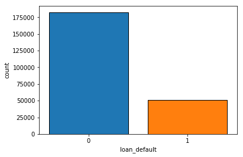

```python
sns.countplot(data=df_loan, x = "loan_default",saturation=1,edgecolor=(0,0,0))
```

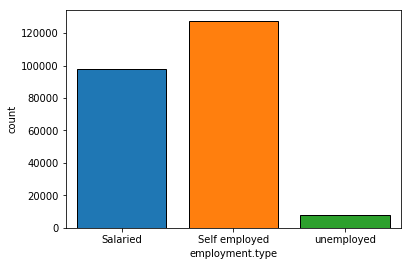

```python
sns.countplot(data=df_loan, x = "employment.type",saturation=1,edgecolor=(0,0,0))
```

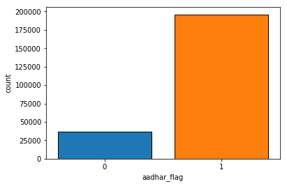

```python
sns.countplot(data=df_loan, x = "aadhar_flag",saturation=1,edgecolor=(0,0,0))
```

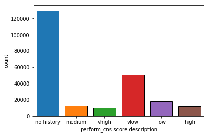

```python
sns.countplot(data=df_loan, x = "perform_cns.score.description",saturation=1,edgecolor=(0,0,0))
```

```
[Text(0.5, 0, '')]
```

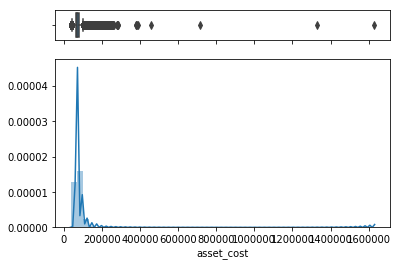

```python
f, (ax_box, ax_hist) = plt.subplots(2, sharex=True, gridspec_kw={"height_ratios": (.15, .85)})
sns.boxplot(df_loan["asset_cost"], ax=ax_box)
sns.distplot(df_loan["asset_cost"], ax=ax_hist)
ax_box.set(xlabel='')
```

```
[Text(0.5, 0, 'disbursed_amount')]
```

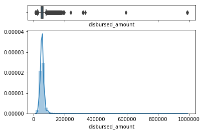

```python
f, (ax_box, ax_hist) = plt.subplots(2, sharex=True, gridspec_kw={"height_ratios": (.15, .85)})
sns.boxplot(df_loan["disbursed_amount"], ax=ax_box)
sns.distplot(df_loan["disbursed_amount"], ax=ax_hist)
ax_box.set(xlabel='disbursed_amount')
```

From the dataset we can see that the asset cost and disbursed amount is not normally distributed.We can try doing a data transformation for a normally distributed data set

```python
df_log = np.log10(df_loan[['asset_cost','disbursed_amount']])
```

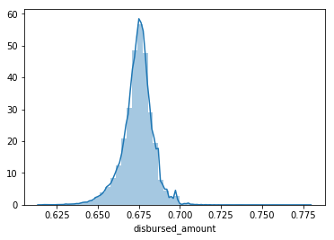

```python
sns.distplot(np.log10(df_log['disbursed_amount']),kde=True)
```

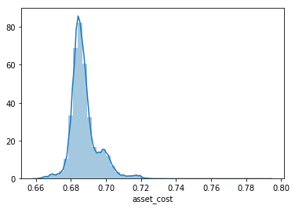

```python
sns.distplot(np.log10(df_log['asset_cost']),kde=True)
```

### Feature selection

```python
df_loan.head()
```

|  | uniqueid | disbursed_amount | asset_cost | ltv | current_pincode_id | date.of.birth | employment.type | disbursaldate | aadhar_flag | perform_cns.score | ... | primary.instal.amt | sec.instal.amt | new.accts.in.last.six.months | delinquent.accts.in.last.six.months | no.of_inquiries | loan_default | Year of birth | age | credit_hist_length | average_account_age |
| --- | --- | --- | --- | --- | --- | --- | --- | --- | --- | --- | --- | --- | --- | --- | --- | --- | --- | --- | --- | --- | --- |
| 0 | 420825 | 50578 | 58400 | 89.55 | 1441 | 01-01-84 | Salaried | 03-08-18 | 1 | 0 | ... | 0 | 0 | 0 | 0 | 0 | 0 | 1984 | 35 | 0.00 | 0.00 |
| 1 | 537409 | 47145 | 65550 | 73.23 | 1502 | 31-07-85 | Self employed | 26-09-18 | 1 | 598 | ... | 1991 | 0 | 0 | 1 | 0 | 1 | 1985 | 34 | 1.11 | 1.11 |
| 2 | 417566 | 53278 | 61360 | 89.63 | 1497 | 24-08-85 | Self employed | 01-08-18 | 1 | 0 | ... | 0 | 0 | 0 | 0 | 0 | 0 | 1985 | 34 | 0.00 | 0.00 |
| 3 | 624493 | 57513 | 66113 | 88.48 | 1501 | 30-12-93 | Self employed | 26-10-18 | 1 | 305 | ... | 31 | 0 | 0 | 0 | 1 | 1 | 1993 | 26 | 1.30 | 0.80 |
| 4 | 539055 | 52378 | 60300 | 88.39 | 1495 | 09-12-77 | Self employed | 26-09-18 | 1 | 0 | ... | 0 | 0 | 0 | 0 | 1 | 1 | 1977 | 42 | 0.00 | 0.00 |

5 rows × 33 columns

```python
df_loan[['asset_cost','disbursed_amount']] = np.log10(df_loan[['asset_cost','disbursed_amount']])
```

## Feature Selection

```python
df_loan2 = df_loan
indexNames = df_loan2[df_loan2['employment.type'] == 'unemployed'].index#dropping the na values converted as unemployed
df_loan2.drop(indexNames , inplace=True)
```

```python
df_loan2['employment.type'].unique()
```

```
array(['Salaried', 'Self employed'], dtype=object)
```

```python
type(df_loan2)
```

```
pandas.core.frame.DataFrame
```

```python
df_loan2.info()
```

```
<class 'pandas.core.frame.DataFrame'>
Int64Index: 225493 entries, 0 to 233153
Data columns (total 33 columns):
uniqueid                               225493 non-null int64
disbursed_amount                       225493 non-null float64
asset_cost                             225493 non-null float64
ltv                                    225493 non-null float64
current_pincode_id                     225493 non-null int64
date.of.birth                          225493 non-null object
employment.type                        225493 non-null object
disbursaldate                          225493 non-null object
aadhar_flag                            225493 non-null int64
perform_cns.score                      225493 non-null int64
perform_cns.score.description          225493 non-null object
pri.no.of.accts                        225493 non-null int64
pri.active.accts                       225493 non-null int64
pri.overdue.accts                      225493 non-null int64
pri.current.balance                    225493 non-null int64
pri.sanctioned.amount                  225493 non-null int64
pri.disbursed.amount                   225493 non-null int64
sec.no.of.accts                        225493 non-null int64
sec.active.accts                       225493 non-null int64
sec.overdue.accts                      225493 non-null int64
sec.current.balance                    225493 non-null int64
sec.sanctioned.amount                  225493 non-null int64
sec.disbursed.amount                   225493 non-null int64
primary.instal.amt                     225493 non-null int64
sec.instal.amt                         225493 non-null int64
new.accts.in.last.six.months           225493 non-null int64
delinquent.accts.in.last.six.months    225493 non-null int64
no.of_inquiries                        225493 non-null int64
loan_default                           225493 non-null int64
Year of birth                          225493 non-null int64
age                                    225493 non-null int64
credit_hist_length                     225493 non-null float64
average_account_age                    225493 non-null float64
dtypes: float64(5), int64(24), object(4)
memory usage: 58.5+ MB
```

```python
df_loan2 = df_loan2.drop(columns = ['date.of.birth','disbursaldate','perform_cns.score.description'])#age and date values
```

```python
df_loan2['employment.type'] = df_loan2['employment.type'].replace('Salaried',1)
df_loan2['employment.type'] = df_loan2['employment.type'].replace('Self employed',0)
```

```python
df_loan2.describe()
```

|  | uniqueid | disbursed_amount | asset_cost | ltv | current_pincode_id | employment.type | aadhar_flag | perform_cns.score | pri.no.of.accts | pri.active.accts | ... | primary.instal.amt | sec.instal.amt | new.accts.in.last.six.months | delinquent.accts.in.last.six.months | no.of_inquiries | loan_default | Year of birth | age | credit_hist_length | average_account_age |
| --- | --- | --- | --- | --- | --- | --- | --- | --- | --- | --- | --- | --- | --- | --- | --- | --- | --- | --- | --- | --- | --- |
| count | 225493.000000 | 225493.000000 | 225493.000000 | 225493.000000 | 225493.000000 | 225493.000000 | 225493.000000 | 225493.000000 | 225493.000000 | 225493.000000 | ... | 2.254930e+05 | 2.254930e+05 | 225493.000000 | 225493.000000 | 225493.000000 | 225493.000000 | 225493.000000 | 225493.000000 | 225493.000000 | 225493.000000 |
| mean | 535677.453783 | 4.722708 | 4.868623 | 74.806634 | 3375.718133 | 0.433974 | 0.837720 | 293.040449 | 2.462360 | 1.053767 | ... | 1.299246e+04 | 3.256845e+02 | 0.386602 | 0.098708 | 0.208845 | 0.217155 | 1983.551991 | 35.448009 | 1.343675 | 0.724761 |
| std | 68337.222749 | 0.101755 | 0.089162 | 11.441890 | 2253.216519 | 0.495622 | 0.368708 | 338.874784 | 5.223012 | 1.952015 | ... | 1.497084e+05 | 1.575617e+04 | 0.959668 | 0.386376 | 0.710085 | 0.412310 | 9.666254 | 9.666254 | 2.375538 | 1.256785 |
| min | 417428.000000 | 4.124504 | 4.568202 | 13.500000 | 1.000000 | 0.000000 | 0.000000 | 0.000000 | 0.000000 | 0.000000 | ... | 0.000000e+00 | 0.000000e+00 | 0.000000 | 0.000000 | 0.000000 | 0.000000 | 1954.000000 | 21.000000 | 0.000000 | 0.000000 |
| 25% | 476481.000000 | 4.672550 | 4.817069 | 68.960000 | 1509.000000 | 0.000000 | 1.000000 | 0.000000 | 0.000000 | 0.000000 | ... | 0.000000e+00 | 0.000000e+00 | 0.000000 | 0.000000 | 0.000000 | 0.000000 | 1977.000000 | 27.000000 | 0.000000 | 0.000000 |
| 50% | 535593.000000 | 4.729999 | 4.850076 | 76.890000 | 2949.000000 | 0.000000 | 1.000000 | 15.000000 | 1.000000 | 0.000000 | ... | 0.000000e+00 | 0.000000e+00 | 0.000000 | 0.000000 | 0.000000 | 0.000000 | 1985.000000 | 34.000000 | 0.000000 | 0.000000 |
| 75% | 594774.000000 | 4.779690 | 4.897440 | 83.730000 | 5682.000000 | 1.000000 | 1.000000 | 680.000000 | 3.000000 | 1.000000 | ... | 2.045000e+03 | 0.000000e+00 | 0.000000 | 0.000000 | 0.000000 | 0.000000 | 1992.000000 | 42.000000 | 2.000000 | 1.100000 |
| max | 671084.000000 | 5.994473 | 6.123510 | 95.000000 | 7345.000000 | 1.000000 | 1.000000 | 890.000000 | 453.000000 | 144.000000 | ... | 2.564281e+07 | 4.170901e+06 | 35.000000 | 20.000000 | 36.000000 | 1.000000 | 1998.000000 | 65.000000 | 39.000000 | 30.900000 |

8 rows × 30 columns

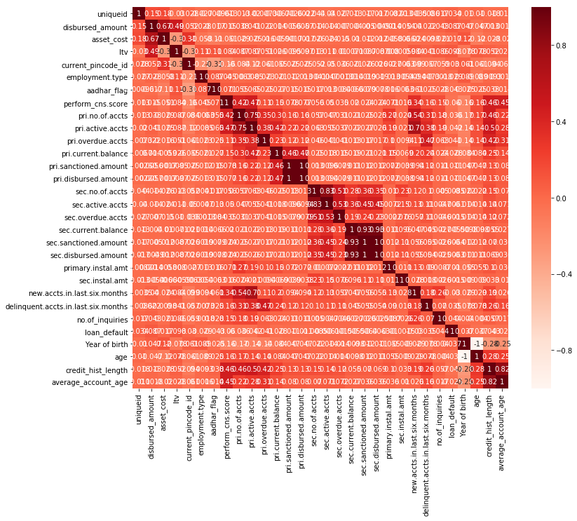

```python
#Using Pearson Correlation
plt.figure(figsize=(12,10))
cor = df_loan2.corr()
sns.heatmap(cor, annot=True, cmap=plt.cm.Reds)
plt.show()
```

```python
#Correlation with output variable
cor_target = abs(cor["loan_default"])
#Selecting highly correlated features
relevant_features = cor_target[cor_target>0.5]
relevant_features
```

```
loan_default    1.0
Name: loan_default, dtype: float64
```

### Backward elimination process for feaure selection

We can see the selected fetures with p value based selection

```python
X = df_loan2.drop('loan_default',axis = 1)
y = df_loan2.loan_default
```

```python
#Backward Elimination
cols = list(X.columns)
pmax = 1
while (len(cols)>0):
    p= []
    X_1 = X[cols]
    X_1 = sm.add_constant(X_1)
    model = sm.OLS(y,X_1).fit()
    p = pd.Series(model.pvalues.values[1:],index = cols)
    pmax = max(p)
    feature_with_p_max = p.idxmax()
    if(pmax>0.05):
        cols.remove(feature_with_p_max)
    else:
        break
selected_features_BE = cols
```

```python
selected_features_BE
```

```
['uniqueid',
 'disbursed_amount',
 'asset_cost',
 'ltv',
 'current_pincode_id',
 'employment.type',
 'aadhar_flag',
 'perform_cns.score',
 'pri.no.of.accts',
 'pri.active.accts',
 'pri.overdue.accts',
 'pri.current.balance',
 'delinquent.accts.in.last.six.months',
 'no.of_inquiries',
 'Year of birth',
 'age',
 'credit_hist_length',
 'average_account_age']
```

# Feature ranking with recursive feature elimination.

Given an external estimator that assigns weights to features (e.g., the coefficients of a linear model), the goal of recursive feature elimination (RFE) is to select features by recursively considering smaller and smaller sets of features. First, the estimator is trained on the initial set of features and the importance of each feature is obtained either through a coef_ attribute or through a feature*importances* attribute. Then, the least important features are pruned from current set of features. That procedure is recursively repeated on the pruned set until the desired number of features to select is eventually reached.

```python
# Recursive Feature Elimination

# load the datasets
dataset = df_loan2
# create a base classifier used to evaluate a subset of attributes
model = LogisticRegression()
# create the RFE model and select 5 attributes
rfe = RFE(model,5)#limiing the number of features to select at 5
rfe = rfe.fit(dataset.drop('loan_default',axis = 1), dataset.loan_default)
# summarize the selection of the attributes
print(rfe.support_)
print(rfe.ranking_)
```

```
[False  True  True False False  True  True False False False  True False
 False False False False False False False False False False False False
 False False False False False]
[15  1  1  6 12  1  1 11  7  4  1 20 18 19 17 25 23 24 13 14 22 21  9  3
  2 10  8  5 16]
```

```python
list1 =list(df_loan2.columns)
list2 = list(rfe.ranking_)
```

```python
fmt = '%-8s%-20s%s'

print(fmt % ('', 'Columnsnames', 'Ranking'))
for i, (list1, list2) in enumerate(zip(list1, list2)):
    print(fmt % (i, list1, list2))
```

```
        Columnsnames        Ranking
0       uniqueid            15
1       disbursed_amount    1
2       asset_cost          1
3       ltv                 6
4       current_pincode_id  12
5       employment.type     1
6       aadhar_flag         1
7       perform_cns.score   11
8       pri.no.of.accts     7
9       pri.active.accts    4
10      pri.overdue.accts   1
11      pri.current.balance 20
12      pri.sanctioned.amount18
13      pri.disbursed.amount19
14      sec.no.of.accts     17
15      sec.active.accts    25
16      sec.overdue.accts   23
17      sec.current.balance 24
18      sec.sanctioned.amount13
19      sec.disbursed.amount14
20      primary.instal.amt  22
21      sec.instal.amt      21
22      new.accts.in.last.six.months9
23      delinquent.accts.in.last.six.months3
24      no.of_inquiries     2
25      loan_default        10
26      Year of birth       8
27      age                 5
28      credit_hist_length  16
```

### Loading the data set with the selected feauture variables

```python
df_loan2 = df_loan2[['disbursed_amount','asset_cost','employment.type','aadhar_flag','pri.overdue.accts','loan_default']]
```

### Treating Outliers

```python
from scipy import stats
```

```python
df_loan2.describe()
```

|  | disbursed_amount | asset_cost | employment.type | aadhar_flag | pri.overdue.accts | loan_default |
| --- | --- | --- | --- | --- | --- | --- |
| count | 225493.000000 | 225493.000000 | 225493.000000 | 225493.000000 | 225493.000000 | 225493.000000 |
| mean | 4.722708 | 4.868623 | 0.433974 | 0.837720 | 0.158989 | 0.217155 |
| std | 0.101755 | 0.089162 | 0.495622 | 0.368708 | 0.553415 | 0.412310 |
| min | 4.124504 | 4.568202 | 0.000000 | 0.000000 | 0.000000 | 0.000000 |
| 25% | 4.672550 | 4.817069 | 0.000000 | 1.000000 | 0.000000 | 0.000000 |
| 50% | 4.729999 | 4.850076 | 0.000000 | 1.000000 | 0.000000 | 0.000000 |
| 75% | 4.779690 | 4.897440 | 1.000000 | 1.000000 | 0.000000 | 0.000000 |
| max | 5.994473 | 6.123510 | 1.000000 | 1.000000 | 25.000000 | 1.000000 |

```python
# detecting the outliers
df_loan3 = df_loan2[(np.abs(stats.zscore(df_loan2)) < 3).all(axis=1)]
print(len(df_loan3))
# the rows we removed
df_loan2.index.difference(df_loan3.index)
```

```
213636
```

```
Int64Index([    14,     16,     94,    152,    243,    316,    329,    355,
               435,    446,
            ...
            232901, 232903, 232909, 232924, 232932, 232957, 232959, 232967,
            233011, 233094],
           dtype='int64', length=11857)
```

### Logistic Regression on non-balanced data

```python
df_loan3['loan_default'].value_counts()
```

```
0    167544
1     46092
Name: loan_default, dtype: int64
```

```python
### Separate input features (X) and target variable (y)
y1 = df_loan3.loan_default
X1 = df_loan3.drop('loan_default', axis=1)
X1_train,X1_test,y1_train,y1_test=train_test_split(X1,y1,test_size=0.25,random_state=0)

## Train model
clf = LogisticRegression().fit(X1_train, y1_train)
y1_pred = clf.predict(X1_test)
print(accuracy_score(y1_pred,y1_test))
```

```
0.7838192065007771
```

```python
print( np.unique(y1_pred))
```

```
[0]
```

### Balancing the data using upsampling the minority class

```python
# Separate majority and minority classes
df_majority = df_loan3[df_loan3.loan_default ==0]
df_minority = df_loan3[df_loan3.loan_default ==1]

# Upsample minority class
df_minority_upsampled = resample(df_minority,
                                 replace=True,     # sample with replacement
                                 n_samples= 167544,    # to match majority class
                                 random_state=123) # reproducible results

# Combine majority class with upsampled minority class
df_upsampled = pd.concat([df_majority, df_minority_upsampled])

# Display new class counts
df_upsampled.loan_default.value_counts()
```

```
1    167544
0    167544
Name: loan_default, dtype: int64
```

```python
# Separate input features (X) and target variable (y)
y_u = df_upsampled.loan_default
X_u = df_upsampled.drop('loan_default', axis=1)
X_u_train,X_u_test,y_u_train,y_u_test=train_test_split(X_u,y_u,test_size=0.25,random_state=0)
# Train model
clf = LogisticRegression().fit(X_u_train, y_u_train)
y_u_pred = clf.predict(X_u_test)
cnf_matrix = metrics.confusion_matrix(y_u_test, y_u_pred)
print(cnf_matrix)
print( np.unique(y_u_pred) )
print( accuracy_score(y_u_pred,y_u_test))
```

```
[[21329 20803]
 [15981 25659]]
[0 1]
0.5609034044788235
```

### Balancing the data using downsampling majority class

```python
# Separate majority and minority classes
df_majority = df_loan3[df_loan3.loan_default==0]
df_minority = df_loan3[df_loan3.loan_default==1]

# Downsample majority class
df_majority_downsampled = resample(df_majority,
                                 replace=False,    # sample without replacement
                                 n_samples= 46092,     # to match minority class
                                 random_state=123) # reproducible results

# Combine minority class with downsampled majority class
df_downsampled = pd.concat([df_majority_downsampled, df_minority])
# Display new class counts
print(df_downsampled.loan_default.value_counts())
```

```
1    46092
0    46092
Name: loan_default, dtype: int64
```

```python
# Separate input features (X) and target variable (y)
y_d = df_downsampled.loan_default
X_d = df_downsampled.drop('loan_default', axis=1)
X_d_train,X_d_test,y_d_train,y_d_test=train_test_split(X_d,y_d,test_size=0.25,random_state=0)
# Train model
clf_d = LogisticRegression().fit(X_d_train, y_d_train)
y_d_pred = clf.predict(X_d_test)
cnf_matrix = metrics.confusion_matrix(y_d_test, y_d_pred)
print(cnf_matrix)
print( accuracy_score(y_d_pred,y_d_test))
```

```
[[5833 5629]
 [4464 7120]]
0.562049813416645
```

Here we can see that balancing the dataset has made no improvement in the accuracy score infact it has reduced the the accuracy score by a significant value.We can see the probability values shown below as the ROC scores

### ROC score

```python
#roc score on imbalanced data
prob_y1= clf.predict_proba(X1)
prob_y1 = [p[1] for p in prob_y1]
print("ROC_AUC Score")
print( roc_auc_score(y1, prob_y1) )
```

```
ROC_AUC Score
0.591436357936581
```

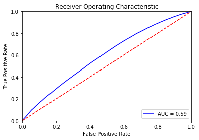

```python
fpr, tpr, threshold = metrics.roc_curve(y1, prob_y1)
roc_auc = metrics.auc(fpr, tpr)
import matplotlib.pyplot as plt
plt.title('Receiver Operating Characteristic')
plt.plot(fpr, tpr, 'b', label = 'AUC = %0.2f' % roc_auc)
plt.legend(loc = 'lower right')
plt.plot([0, 1], [0, 1],'r--')
plt.xlim([0, 1])
plt.ylim([0, 1])
plt.ylabel('True Positive Rate')
plt.xlabel('False Positive Rate')
plt.show()
```

```
ROC_AUC Score
0.5921253604443046
```

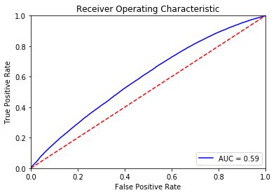

```python
#roc score on downsampled data
# Predict class probabilities
prob_y_d = clf_d.predict_proba(X_d)

prob_y_d = [p[1] for p in prob_y_d]
print("ROC_AUC Score")
print( roc_auc_score(y_d, prob_y_d) )
fpr, tpr, threshold = metrics.roc_curve(y_d, prob_y_d)
roc_auc = metrics.auc(fpr, tpr)
plt.title('Receiver Operating Characteristic')
plt.plot(fpr, tpr, 'b', label = 'AUC = %0.2f' % roc_auc)
plt.legend(loc = 'lower right')
plt.plot([0, 1], [0, 1],'r--')
plt.xlim([0, 1])
plt.ylim([0, 1])
plt.ylabel('True Positive Rate')
plt.xlabel('False Positive Rate')
plt.show()
```

```
ROC_AUC Score
0.5915636857030231
```

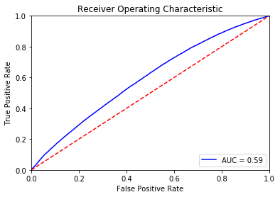

```python
#roc score on upsampled dataset
prob_y_u= clf.predict_proba(X_u)
prob_y_u = [p[1] for p in prob_y_u]

print("ROC_AUC Score")
print(roc_auc_score(y_u, prob_y_u))

fpr, tpr, threshold = metrics.roc_curve(y_u, prob_y_u)
roc_auc = metrics.auc(fpr, tpr)
plt.title('Receiver Operating Characteristic')
plt.plot(fpr, tpr, 'b', label = 'AUC = %0.2f' % roc_auc)
plt.legend(loc = 'lower right')
plt.plot([0, 1], [0, 1],'r--')
plt.xlim([0, 1])
plt.ylim([0, 1])
plt.ylabel('True Positive Rate')
plt.xlabel('False Positive Rate')
plt.show()
```

Decision trees often perform well on imbalanced datasets because their hierarchical structure allows them to learn signals from both classes.

### Random forest classifier

```python
# Separate input features (X) and target variable (y)
y = df_loan3.loan_default
X = df_loan3.drop('loan_default', axis=1)
X_train, X_test, y_train, y_test = train_test_split(X, y, test_size=0.3,random_state=0)
# Train model
clf_4 = RandomForestClassifier()
clf_4.fit(X_train,y_train)
# Predict on training set
pred_y_4 = clf_4.predict(X_test)
# Is our model predicting just one class?
print( np.unique( pred_y_4 ) )
# How's our accuracy?
print(( accuracy_score(y_test, pred_y_4) )*100)
# Train model
clf_4 = RandomForestClassifier()
clf_4.fit(X, y)
```

```
[0 1]
72.8183364278916
```

```
RandomForestClassifier(bootstrap=True, class_weight=None, criterion='gini',
            max_depth=None, max_features='auto', max_leaf_nodes=None,
            min_impurity_decrease=0.0, min_impurity_split=None,
            min_samples_leaf=1, min_samples_split=2,
            min_weight_fraction_leaf=0.0, n_estimators=10, n_jobs=None,
            oob_score=False, random_state=None, verbose=0,
            warm_start=False)
```

```
ROC_AUC Score
0.9890643599890231
```

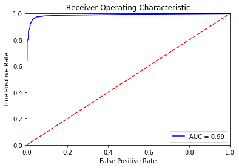

```python
#AUC ROC SCORE AND CURVE FOR RANDOM FOREST
prob_y1= clf_4.predict_proba(X)
prob_y1 = [p[1] for p in prob_y1]
print("ROC_AUC Score")
print( roc_auc_score(y1, prob_y1) )
fpr, tpr, threshold = metrics.roc_curve(y1, prob_y1)
roc_auc = metrics.auc(fpr, tpr)
plt.title('Receiver Operating Characteristic')
plt.plot(fpr, tpr, 'b', label = 'AUC = %0.2f' % roc_auc)
plt.legend(loc = 'lower right')
plt.plot([0, 1], [0, 1],'r--')
plt.xlim([0, 1])
plt.ylim([0, 1])
plt.ylabel('True Positive Rate')
plt.xlabel('False Positive Rate')
plt.show()
```

### Random forest classifier on downsampled data

```python
#Random forest on downsampled data
# Separate input features (X) and target variable (y)
y_d = df_downsampled.loan_default
X_d = df_downsampled.drop('loan_default', axis=1)
X_d_train,X_d_test,y_d_train,y_d_test=train_test_split(X_d,y_d,test_size=0.25,random_state=0)
clf_4 = RandomForestClassifier()
clf_4.fit(X_d_train,y_d_train)
# Predict on training set
pred_y_4 = clf_4.predict(X_d_test)
# Is our model predicting just one class?
print( np.unique( pred_y_4 ) )
# How's our accuracy?
print(( accuracy_score(y_d_test, pred_y_4) )*100)
# Train model
clf_4 = RandomForestClassifier()
clf_4.fit(X_d, y_d)
```

```
[0 1]
53.10682981862362
```

```
RandomForestClassifier(bootstrap=True, class_weight=None, criterion='gini',
            max_depth=None, max_features='auto', max_leaf_nodes=None,
            min_impurity_decrease=0.0, min_impurity_split=None,
            min_samples_leaf=1, min_samples_split=2,
            min_weight_fraction_leaf=0.0, n_estimators=10, n_jobs=None,
            oob_score=False, random_state=None, verbose=0,
            warm_start=False)
```

```
ROC_AUC Score
0.989080693963751
```

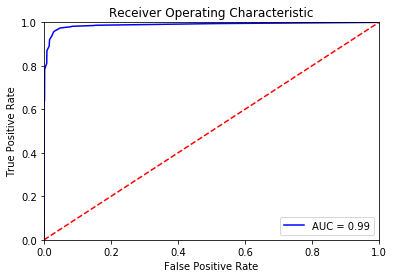

```python
#ROC score and for random forest classifier downsampled data

prob_y1= clf_4.predict_proba(X_d)
prob_y1 = [p[1] for p in prob_y1]
print("ROC_AUC Score")
print( roc_auc_score(y_d, prob_y1) )
fpr, tpr, threshold = metrics.roc_curve(y_d, prob_y1)
roc_auc = metrics.auc(fpr, tpr)
plt.title('Receiver Operating Characteristic')
plt.plot(fpr, tpr, 'b', label = 'AUC = %0.2f' % roc_auc)
plt.legend(loc = 'lower right')
plt.plot([0, 1], [0, 1],'r--')
plt.xlim([0, 1])
plt.ylim([0, 1])
plt.ylabel('True Positive Rate')
plt.xlabel('False Positive Rate')
plt.show()
```

### Random forest classifier on upsampled data

```python
# Separate input features (X) and target variable (y)
y_u = df_upsampled.loan_default
X_u = df_upsampled.drop('loan_default', axis=1)
X_u_train,X_u_test,y_u_train,y_u_test=train_test_split(X_u,y_u,test_size=0.25,random_state=0)
clf_4 = RandomForestClassifier()
clf_4.fit(X_u_train,y_u_train)
# Predict on training set
pred_y_4 = clf_4.predict(X_u_test)
# Is our model predicting just one class?
print( np.unique( pred_y_4 ) )
# How's our accuracy?
print(( accuracy_score(y_u_test, pred_y_4) )*100)
# Train model
clf_4 = RandomForestClassifier()
clf_4.fit(X_u, y_u)
```

```
[0 1]
84.86129016855274
```

```
RandomForestClassifier(bootstrap=True, class_weight=None, criterion='gini',
            max_depth=None, max_features='auto', max_leaf_nodes=None,
            min_impurity_decrease=0.0, min_impurity_split=None,
            min_samples_leaf=1, min_samples_split=2,
            min_weight_fraction_leaf=0.0, n_estimators=10, n_jobs=None,
            oob_score=False, random_state=None, verbose=0,
            warm_start=False)
```

This is a significant improvement from the past accuracy score

```
ROC_AUC Score
0.997922665856164
```

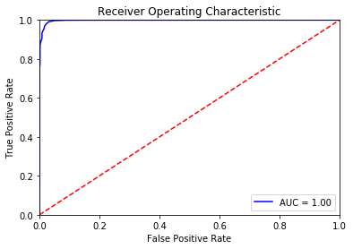

```python
#ROC score for random forest classifier upsampled data

prob_y1= clf_4.predict_proba(X_u)
prob_y1 = [p[1] for p in prob_y1]
print("ROC_AUC Score")
print( roc_auc_score(y_u, prob_y1) )
fpr, tpr, threshold = metrics.roc_curve(y_u, prob_y1)
roc_auc = metrics.auc(fpr, tpr)
plt.title('Receiver Operating Characteristic')
plt.plot(fpr, tpr, 'b', label = 'AUC = %0.2f' % roc_auc)
plt.legend(loc = 'lower right')
plt.plot([0, 1], [0, 1],'r--')
plt.xlim([0, 1])
plt.ylim([0, 1])
plt.ylabel('True Positive Rate')
plt.xlabel('False Positive Rate')
plt.show()
```

### References

https://scikit-learn.org/stable/modules/generated/sklearn.feature_selection.RFE.html#sklearn.feature_selection.RFE

https://stackoverflow.com/questions/35494282/freeing-memory-tied-to-errors-in-ipython-notebook

https://www.datacamp.com/community/tutorials/feature-selection-python

https://elitedatascience.com/imbalanced-classes

https://stackoverflow.com/questions/27663924/printing-2-evenly-populated-lists-side-by-side-evenly/27663989

https://stats.stackexchange.com/questions/132777/what-does-auc-stand-for-and-what-is-it

https://towardsdatascience.com/understanding-random-forest-58381e0602d2

https://stackoverflow.com/questions/25009284/how-to-plot-roc-curve-in-python

https://machinelearningmastery.com/assessing-comparing-classifier-performance-roc-curves-2/